# Analysis of subject 2

Joern Alexander Quent

28/03/2021

# Summary

Overall, I think the data of the participant is very encouraging. a) there was clear learning and b) the movement also seems to be varied and long enough. With the current set-up (84 trials) we get circa 14 minutes of movement from the task.

# Trial results

## Evidence for learning

### Learning curve

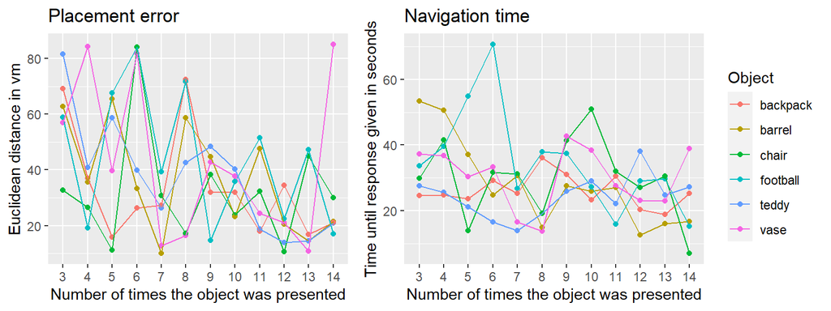

We clearly see that both the placement error (i.e. Euclidean distance) as well as the navigation time (i.e. time until the object location was retrieved) decrease over time. Block 1, where the object is immediately visible was excluded.

### Compare Block 2 with Block 7

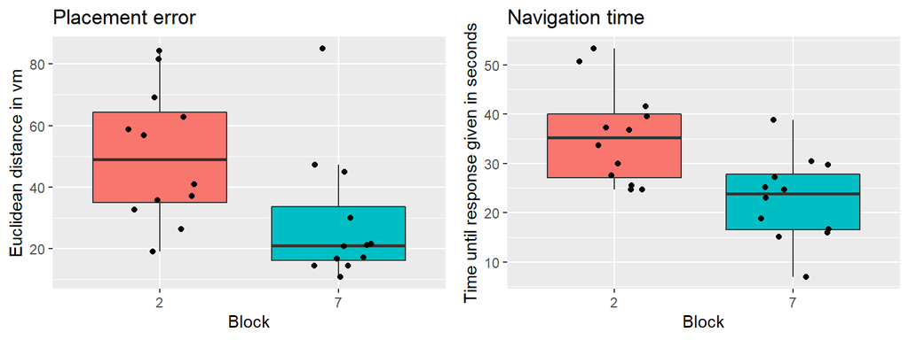

We have the same pattern when we compare the performance of Block 2 with Block 7.

### Modelling learning

Next, I thought a bit how we can model the data. Doeller et al. (2010) simply correlated 1/(mean of subject) with the grid score but I don’t think that this is good solution.

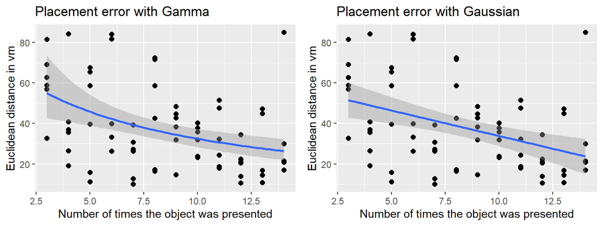

That is why I modeled the learning curve 1) with Gamma distribution and 2) with Gaussian distribution. While Bayes factor comparing both models favours the one with the Gaussian distribution I don’t think it is the correct one a) because we know that theoretically it is wrong and b) because of the posterior checks:

#### Posterior predictive checks

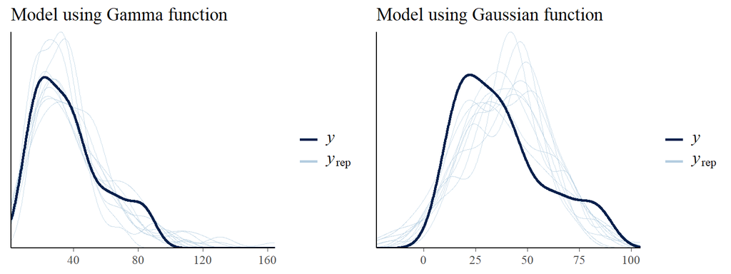

The comparison of the samples with the real data shows the Gamma distribution (see left) does a much better job accounting for the data. There more options to explore (e.g. modelling whether the predictor should be treated as continuous or monotone) as more data comes in.

In general, I think a good way to deal with this data would be a hierarchical model with subject as a random factor using a Gamma distribution. We can then use the slope and intercept to correlate them with the grid-coherence.

# Position tracker

## Polar histogram of heading angle during movement

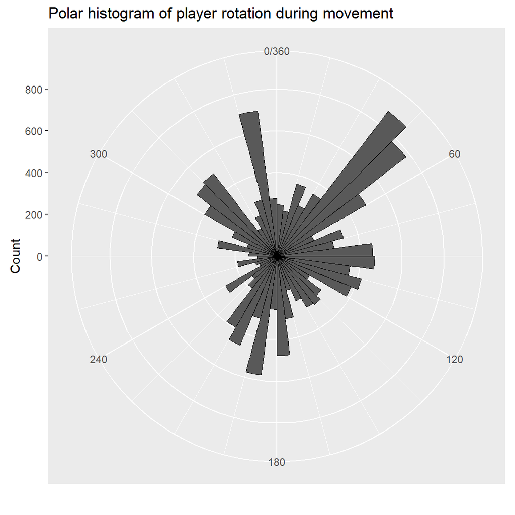

Overall the heading angle looks fairly uniform but I didn’t find any plots to compare our data with so it is heard to tell.

## Show position on 2D plane per time

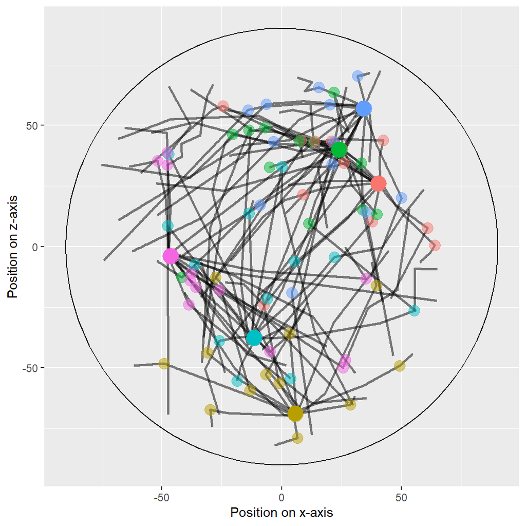

The figure above illustrates the individual trajectories, true object locations (larger non-transparent colour points) and the retrieved locations (smaller transparent colour points).

## How long did the participant spend moving?

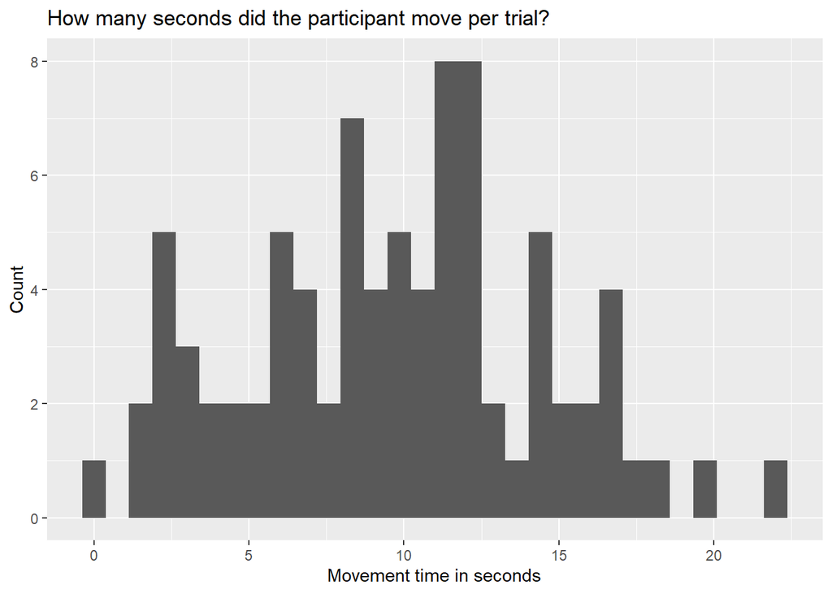

An important question for the fMRI-version of the experiment is how long per trial did the participant spend on moving forward, which was on average 9.7 seconds movement per trial.

# Other information

| Description | Value | Measure |
| --- | --- | --- |
| How long were the estimated cue periods? | 2.01 | seconds |
| How long were the estimated delay periods? | 4.01 | seconds |
| How long was the average trial? | 34.91 | seconds |
| How long was the total time spend moving? | 13.58 | minutes |
| What was the average Frames Per Second? | 19.00 | fps |
| What was the average speed? | 7.90 | vm/s |